# Making America Weak: Consequences of Underinvestment in Renewable Energy

Sarah Mathey

December 12, 2025

## Making America Weak: Consequences of Underinvestment in Renewable Energy

[figure not shown]

In the News

This project was inspired by The New York Times *Power Moves* article: [*There’s a Race to Power the Future. China is Pulling Away.*](https://www.nytimes.com/interactive/2025/06/30/climate/china-clean-energy-power.html)

## The United States lags behind its peers

[interactive chart not shown]

## Global positioning

[interactive chart not shown]

## China has made deep investments, especially in solar

- Operating plants
- US investments
- Chinese investments

China has 4X the number of 20+ MW solar plants as the US, producing 4X the amount of energy  
Note: A 20 MW+ solar plant is a utility-scale plant.

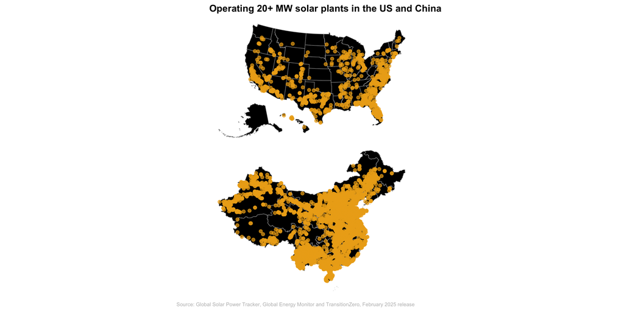

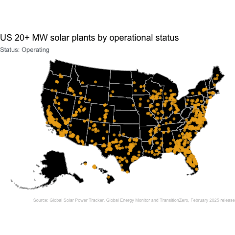

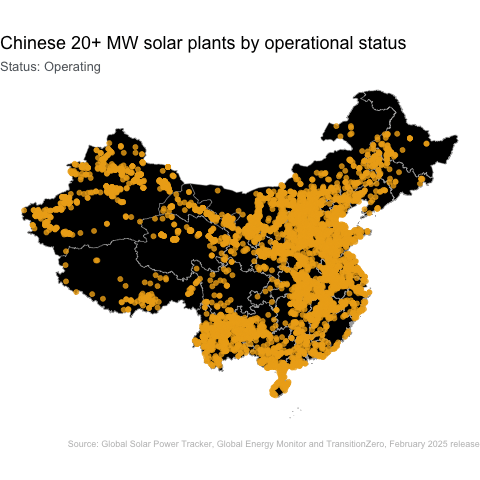

## Pulling back on federal investments will further erode our global standing

- 2025
- Widening investment gap

[figure not shown]

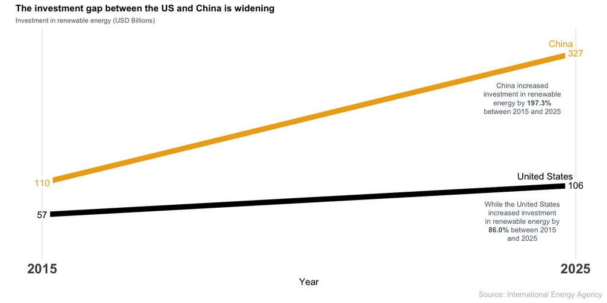

## Going forward

In order to keep America great, we need to be looking forward, not back. This means investing in basic science and new techonological development, not relying on our current dominance in fossil fuels.

Further investigation into China’s lead in developing and manufacturing renewable energy technology and the economic and political benefits accrued by exporting these tools should be conducted.

## Additional Resources

[**Click here to compare the US to other countries**](https://sarah-mathey.shinyapps.io/shiny_app/)

[**Use this link to explore this work on your own**](https://sarahmathey.github.io//data_viz//peer-review)

## Data Sources

- IEA (2025), Energy investment across regions and sectors, 2015 and 2025, IEA, Paris https://www.iea.org/data-and-statistics/charts/energy-investment-across-regions-and-sectors-2015-and-2025, Licence: CC BY 4.0
- IRENA (2025), Renewable Energy Statistics 2025, International Renewable Energy Agency, Abu Dhabi. https://www.irena.org/Publications/2025/Jul/Renewable-energy-statistics-2025
- Global Solar Power Tracker, Global Energy Monitor and TransitionZero, February 2025 release. https://globalenergymonitor.org/wp-content/uploads/2025/02/Global-Solar-Power-Tracker-February-2025.xlsx